# Fig1FG

N. Alcala

2025-05-01

# Figure 1 panels F and G (and associated supplementary figures): immune cell analysis from bulk RNA-seq data

This document produces pannels F and G from Figure 1 from the lungNENomics manuscript, which provide immune cell analyses from bulk RNA-seq data, as well as their associated supplementary figures.

### Load libraries

Set colors

```r
colors_clusters = c("Ca A1"="#999933", "Ca A2"= "#DDCC77", "Ca B"= "#117733", "sc-enriched"="#CC6677",
                    "Typical"="#9DB802","Atypical"="#025B0E","undetermined"="#CEDB80",
                    "LCNEC"="#824833" ,"SCLC"="#000000",
                    SINET = "#2ad4ffff" , "LUAD"="#ff80e5ff", "LUSC"="#8080ffff")
```

### Extended Data Figure 1C: immune archetypes

We compute the immune archetypes following the precedure from Combes et al. Cell 2019. Note that since this is a pan-cancer signature, each archetype is defined relative to other tumors, thus we use other lung data from the TCGA, that we have reprocessed internally to avoid batch effects (see methods from the manuscript).

### Data preparation

We load the metadata

```r
Attributes = read_tsv(unzip('../../Data/GabrielEtAl2020/Attributes.txt.zip')[1])
load("/data/lungNENomics/work/Descriptive_manuscript_data/MOFA/MOFA.Exp.Meth.Alt.CNV_lungNENomicsCombined/ParetoTI/variables_archetypes_MOFA_LNET.RData") # data also contained in Table S1
gigascience_attributes = read_tsv("/data/lungNENomics/work/SextonoatesA/Attributes.txt")
```

```r
var_LNET$sample_id = as.character(var_LNET$sample_id)
var_LNET$group = var_LNET$archetype_k4_LF3_label

var_cli = bind_rows(var_LNET, Attributes %>% filter(Histopathology_simplified%in%c("LCNEC","SCLC")) %>%
                      mutate(sample_id = Sample_ID, group=Histopathology_simplified) %>% dplyr::select(sample_id,group) )
var_cli = bind_rows(var_cli,tibble(sample_id=c("LCNEC3T","LCNEC4T"),group="LCNEC") )
```

We load the expression data for the datasets

```r
# We load the list of marker genes for each archetype
immune_arc_genes = readxl::read_xlsx("../../Data/ImmuneArchetypes/immune_arc_genes.xlsx")

# We load the lungNENomics data
expr = load("/data/lungNENomics/work/Descriptive_manuscript_data/RNA_sequencing_data/gene_TPM_matrix_PCA_LCNEC_SCLC_ITH_TR.RData")
annot <- load("/data/lungNENomics/work/Descriptive_manuscript_data/gencode_hg38_v33.RData")
gene_TPM_matrix = left_join(gene_TPM_matrix,ref.33.gene %>% dplyr::select(gene_id,gene_name) ) %>% relocate(gene_name , .after=gene_id)
## also get TPM from TCGA lung cancer for reference
load("/data/lungNENomics/files/Internal_Data_2023/RNASeq/Analyses-LungNENomics/TCGA-LUAD-Tumors-534/out_RNAseq-transcript-nf-2.2/Robjects/gene_1pass.SE.rda")
gene_TPM_matrix.LUAD = assay(gene_1pass.SE,"abundance_TPM")

load("/data/lungNENomics/files/Internal_Data_2023/RNASeq/Analyses-LungNENomics/TCGA-LUSC-Tumors-502/out_RNAseq-transcript-nf-2.2/Robjects/gene_1pass.SE.rda")
gene_TPM_matrix.LUSC = assay(gene_1pass.SE,"abundance_TPM")

rm(gene_1pass.SE)
gc()
```

```
##             used  (Mb) gc trigger   (Mb)  max used   (Mb)
## Ncells   6739371 360.0   12570827  671.4   8798673  469.9
## Vcells 106393340 811.8  317354751 2421.3 359036503 2739.3
```

We merge the different expression matrices and extract the features for classification

```r
# check presence of features
immune_arc_genes.list = unlist(immune_arc_genes)
immune_arc_genes.list = immune_arc_genes.list[!is.na(immune_arc_genes.list)]

immune_arc_genes.list[which( !immune_arc_genes.list %in% gene_TPM_matrix$gene_name )] # replace with YARS1 alias
```

```
## Treg21
## "YARS"
```

```r
immune_arc_genes[immune_arc_genes=="YARS"] = "YARS1"

# merge lungNENomics and TCGA datasets
all( gene_TPM_matrix$gene_id == rownames(gene_TPM_matrix.LUAD) )
```

```
## [1] TRUE
```

```r
all( gene_TPM_matrix$gene_id == rownames(gene_TPM_matrix.LUSC) )
```

```
## [1] TRUE
```

```r
gene_TPM_matrix.LN_TCGA = bind_cols(gene_TPM_matrix,gene_TPM_matrix.LUAD,gene_TPM_matrix.LUSC)

arc.features = tibble(sample = colnames(gene_TPM_matrix.LN_TCGA)[-(1:2)],
                      Tcell.sig.TPM   = log2(colMeans( (gene_TPM_matrix.LN_TCGA %>% filter(gene_name%in% immune_arc_genes$Tcell ) )[,-c(1:2)]+1) ),
                      Myeloid.sig.TPM = log2(colMeans( (gene_TPM_matrix.LN_TCGA %>% filter(gene_name%in% immune_arc_genes$Myeloid ) )[,-c(1:2)]+1 )),
                      Stroma.sig.TPM  = log2(colMeans( (gene_TPM_matrix.LN_TCGA %>% filter(gene_name%in% immune_arc_genes$Stroma ) )[,-c(1:2)]+1 )),
                      Treg.sig.TPM  = log2(colMeans( (gene_TPM_matrix.LN_TCGA %>% filter(gene_name%in% immune_arc_genes$Treg ) )[,-c(1:2)]+1 )),
                      CD4.sig.TPM  = log2(colMeans( (gene_TPM_matrix.LN_TCGA %>% filter(gene_name%in% immune_arc_genes$CD4 ) )[,-c(1:2)]+1 )),
                      CD8.sig.TPM  = log2(colMeans( (gene_TPM_matrix.LN_TCGA %>% filter(gene_name%in% immune_arc_genes$CD8 ) )[,-c(1:2)]+1 )),
                      DC2.sig.TPM  = log2(colMeans( (gene_TPM_matrix.LN_TCGA %>% filter(gene_name%in% immune_arc_genes$cDC2 ) )[,-c(1:2)]+1 )),
                      DC1.sig.TPM  = log2(colMeans( (gene_TPM_matrix.LN_TCGA %>% filter(gene_name%in% immune_arc_genes$cDC1 ) )[,-c(1:2)]+1 )),
                      Macro.sig.TPM  = log2(colMeans( (gene_TPM_matrix.LN_TCGA %>% filter(gene_name%in% immune_arc_genes$Macrophage ) )[,-c(1:2)]+1 )),
                      ClasMono.sig.TPM  = log2(colMeans( (gene_TPM_matrix.LN_TCGA %>% filter(gene_name%in% immune_arc_genes$ClassicalMonocytes ) )[,-c(1:2)]+1 )),
                      CD4CD8ratio  = log2(colMeans( (gene_TPM_matrix.LN_TCGA %>% filter(gene_name%in% immune_arc_genes$CD4 ) )[,-c(1:2)] )/colMeans( (gene_TPM_matrix.LN_TCGA %>% filter(gene_name%in% immune_arc_genes$CD8 ) )[,-c(1:2)] ) ),
                      DC2DC1ratio  = log2(colMeans( (gene_TPM_matrix.LN_TCGA %>% filter(gene_name%in% immune_arc_genes$cDC2 ) )[,-c(1:2)] )/colMeans( (gene_TPM_matrix.LN_TCGA %>% filter(gene_name%in% immune_arc_genes$cDC1 ) )[,-c(1:2)] ) ),
                      MonoMacratio  = log2(colMeans( (gene_TPM_matrix.LN_TCGA %>% filter(gene_name%in% immune_arc_genes$ClassicalMonocytes ) )[,-c(1:2)] )/colMeans( (gene_TPM_matrix.LN_TCGA %>% filter(gene_name%in% immune_arc_genes$Macrophage ) )[,-c(1:2)] ) ),
                      )
```

We remove the two samples with swapped RNAseq data

```r
arc.features = arc.features %>% filter(!sample%in%c("LNEN246_TU","LNEN251_TU1") )
```

We further normalize and process the data

```r
# convert to rank percentile per row
arc.features.abs = arc.features
arc.features = arc.features[,1:11]
arc.features[,-1] = apply(arc.features[,-1],2,rank)/nrow(arc.features)

arc.features = left_join(arc.features , var_cli %>% dplyr::select(sample_id,group) ,
                         by=c(sample="sample_id"))
# add LUAD and LUSC. 495 samples, 534 LUAD, 502 LUSC => total 1531
arc.features$group[495+1:534] = "LUAD"
arc.features$group[495+534+1:502] = "LUSC"


arc.features$group = factor(arc.features$group,levels=c("Ca A1","Ca A2","Ca B","sc-enriched","LCNEC","SCLC","LUAD","LUSC"))
arc.features.df = data.frame(arc.features)
rownames(arc.features.df) = arc.features.df$sample
colnames(arc.features.df) = str_remove(colnames(arc.features.df),".sig.TPM")

arc.features.df.long = arc.features.df %>% filter(!is.na(group)) %>% pivot_longer( cols=c(Tcell:ClasMono),names_to = "Feature",values_to = "Score" )
arc.features.df.long$Feature = factor(arc.features.df.long$Feature,levels=c("Tcell","Myeloid","Stroma", "Treg","CD4","CD8","DC2","DC1","Macro","ClasMono") )
```

#### Clustering

We perform UMAP following Combes et al. for vizualisation, and louvain clustering to group samples

```r
## 3-feature scores
library(umap)
umap3f = umap(arc.features.df[,2:11])

louvain_clustering = function( latent_dat,knearest=100, Resolution=0.5){
  set.seed(12345)
  PCvalues = latent_dat
  dim(PCvalues)
  info.spatial = as.data.frame(PCvalues)
  knn.norm = FNN::get.knn(as.matrix(PCvalues), k = knearest)
  knn.norm = data.frame(from = rep(1:nrow(knn.norm$nn.index),
                                   k=knearest), to = as.vector(knn.norm$nn.index), weight = 1/(1 + as.vector(knn.norm$nn.dist)))
  nw.norm = igraph::graph_from_data_frame(knn.norm, directed = FALSE)
  nw.norm = igraph::simplify(nw.norm)
  print("Computing louvain clusters ")
  lc.norm = igraph::cluster_louvain(nw.norm,resolution = Resolution)
  print("Nb louvain community")
  clusterlabel <-  as.vector(igraph::membership(lc.norm))
  print("Nb community after merging")
  print(length(unique(clusterlabel)))

  return("cluster_label"=clusterlabel)
}

louvain_n100_r0.5 = louvain_clustering(arc.features.df[,2:4],100,0.5)
```

```
## [1] "Computing louvain clusters "
## [1] "Nb louvain community"
## [1] "Nb community after merging"
## [1] 4
```

```r
arc.features.df$cluster = cluster=paste0("C",louvain_n100_r0.5)

### add clustering info
arc.features.df.long = bind_cols(arc.features.df,arc.features.abs[,12:14]) %>%
  filter(!is.na(group)) %>% pivot_longer( cols=c(Tcell:Treg,DC1,DC2,CD4CD8ratio:MonoMacratio),names_to = "Feature",values_to = "Score" )
arc.features.df.long$Feature = factor(arc.features.df.long$Feature,levels=c("Tcell","Myeloid","Stroma","Treg","DC1","DC2","CD4CD8ratio", "DC2DC1ratio", "MonoMacratio")) #"CD4","CD8","DC2","DC1","Macro","ClasMono") )
```

#### Labelling of clusters

We first plot the clusters and their marker values

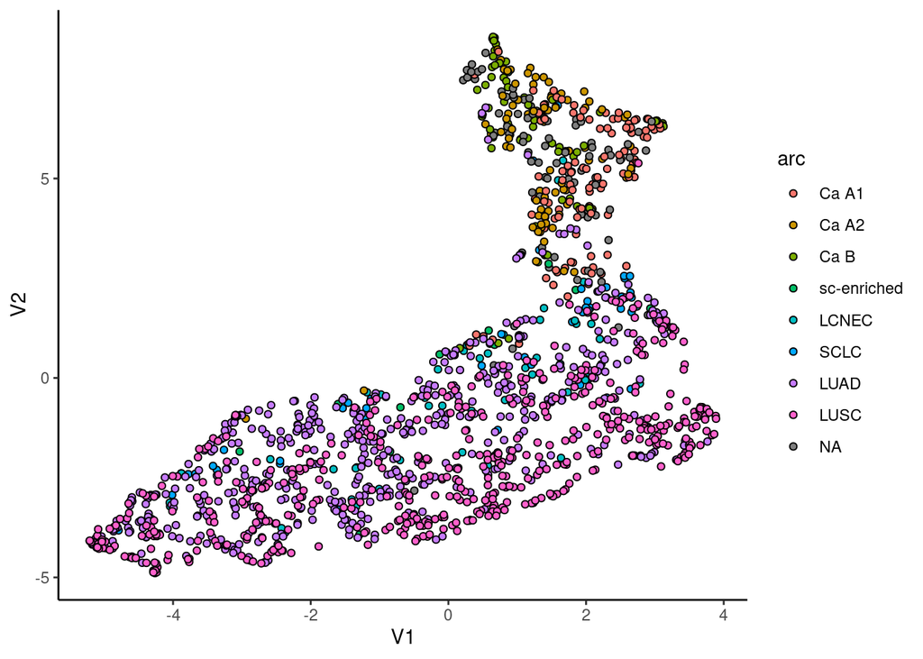

```r
ggplot(bind_cols(as_tibble(umap3f$layout),arc=arc.features.df$group,cluster=factor(louvain_n100_r0.5) ),
       aes(x=V1,y=V2,fill=arc,fill=cluster) ) +
  geom_point(shape=21) + theme_classic() # 6 communities as in original paper
```

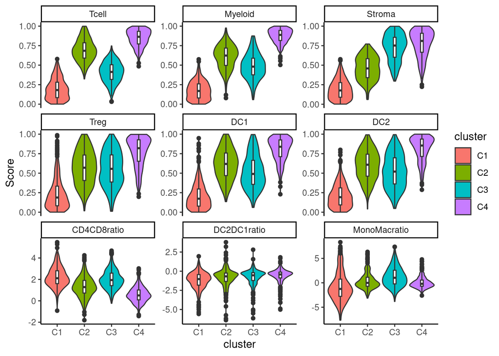

```r
ggplot( arc.features.df.long , aes(x=cluster,y=Score,fill=cluster)) +
  geom_violin(scale = "width") +geom_boxplot(width=0.1,fill="white") + facet_wrap(.~Feature,scales = "free_y")+ theme_classic()
```

Based on the plots, we identify the following correspondance: T M S C4: + + + => 1. Immune stromal (90 90 80) C2: +(75) +(75) ~(50) => 2. Immune rich (80 80 35) C3: - - + => 5. Immune desert (20 20 70) C1: - - - => 6. Immune stroma desert (15 10 20)

We rename and reorder for fig

```r
immarc6 = c(Immune_rich="red",Immune_stromal="darkgreen",T_cell_centric="darkblue",
            Myeloid_centric="gray",Immune_desert="yellow",Immune_stroma_desert="orange")

arc.features.df.long$cluster.label = NA
arc.features.df.long$cluster.label[arc.features.df.long$cluster=="C4"] = "Immune_stromal"
arc.features.df.long$cluster.label[arc.features.df.long$cluster=="C2"] = "Immune_rich"
arc.features.df.long$cluster.label[arc.features.df.long$cluster=="C3"] = "Immune_desert"
arc.features.df.long$cluster.label[arc.features.df.long$cluster=="C1"] = "Immune_stroma_desert"
arc.features.df.long$cluster.label = factor(arc.features.df.long$cluster.label,
                                            levels=c("Immune_rich","Immune_stromal","T_cell_centric","Myeloid_centric","Immune_desert","Immune_stroma_desert"))

FigS61 = ggplot( arc.features.df.long %>% filter(Feature %in% c("Tcell","Myeloid","Stroma","Treg","DC1","DC2","CD4CD8ratio","DC2DC1ratio","MonoMacratio")) ,
        aes(x=cluster.label,y=Score,fill=cluster.label)) + geom_violin(scale = "width") +  geom_boxplot(width=0.2,fill="white")+
  scale_fill_manual(values=immarc6) + facet_wrap(.~Feature,scales = "free_y") +
  theme_classic() + theme(axis.text.x=element_blank(),axis.ticks.x = element_blank(),axis.line.x=element_blank()) +xlab("")


FigS61b = ggplot( arc.features.df.long %>% filter(Feature %in% c("Tcell","Myeloid","Stroma","Treg","DC1","DC2","CD4CD8ratio","DC2DC1ratio","MonoMacratio")) ,
        aes(x=group,y=Score,fill=group)) + geom_violin(scale = "width") +  geom_boxplot(width=0.2,fill="white")+
  scale_fill_manual(values=colors_clusters) + facet_wrap(.~Feature,scales = "free_y") +
  theme_classic() + theme(axis.text.x=element_blank(),axis.ticks.x = element_blank(),axis.line.x=element_blank()) +xlab("")


ggsave(filename="../../../Figures/Supplementary_Figure_S61_immune_v2.svg",
         (FigS61/FigS61b) + plot_annotation(tag_levels = 'a') & theme(plot.tag = element_text(face = "bold")),height=2*4,width=3*2)
ggsave(filename="../../../Figures/Supplementary_Figure_S61_immune_v2.pdf",
       FigS61/FigS61b + plot_annotation(tag_levels = 'a') & theme(plot.tag = element_text(face = "bold")),height=2*4,width=3*2)
```

Save the table

```r
arc.features.df.wide = arc.features.df.long %>% pivot_wider(values_from=Score,names_from=Feature)

write_csv(arc.features.df.wide,file = "/data/lungNENomics/work/alcalan/tomoveto_Descriptive_manuscript_data/RNAseq/TableS11_immune_archetypes_v2.csv")
```

We quantify arc proportions in each group

```r
Immarc6.tib = arc.features.df.long %>% filter(Feature %in% c("Tcell","Myeloid","Stroma"))
Immarc6.tib = table(Immarc6.tib$group,Immarc6.tib$cluster.label)
Immarc6.tib = sweep(Immarc6.tib,1,rowSums(Immarc6.tib),"/")
Immarc6.tib = as_tibble(as.data.frame(Immarc6.tib))
colnames(Immarc6.tib)[1:2] = c("group","immune.archetype")

Immarc6.tib2 = arc.features.df.long %>% filter(Feature %in% "Tcell")
Immarc6.tib2 = table(Immarc6.tib2$group,Immarc6.tib2$cluster.label)

fisher.test(Immarc6.tib2[1:4,],simulate.p.value = T)# significant differences
```

```
##
##  Fisher's Exact Test for Count Data with simulated p-value (based on
##  2000 replicates)
##
## data:  Immarc6.tib2[1:4, ]
## p-value = 0.0004998
## alternative hypothesis: two.sided
```

```r
fisher.test(Immarc6.tib2[1:3,],simulate.p.value = T)# no significant differences between A1 A2 and B
```

```
##
##  Fisher's Exact Test for Count Data with simulated p-value (based on
##  2000 replicates)
##
## data:  Immarc6.tib2[1:3, ]
## p-value = 0.1224
## alternative hypothesis: two.sided
```

```r
fisher.test(Immarc6.tib2[1:2,],simulate.p.value = T)# small diff between A1 and A2, A2 a bit more stroma
```

```
##
##  Fisher's Exact Test for Count Data with simulated p-value (based on
##  2000 replicates)
##
## data:  Immarc6.tib2[1:2, ]
## p-value = 0.03848
## alternative hypothesis: two.sided
```

```r
fisher.test(Immarc6.tib2[c(1,3),],simulate.p.value = T)# no differences between A1 and B
```

```
##
##  Fisher's Exact Test for Count Data with simulated p-value (based on
##  2000 replicates)
##
## data:  Immarc6.tib2[c(1, 3), ]
## p-value = 0.3973
## alternative hypothesis: two.sided
```

```r
fisher.test(Immarc6.tib2[c(1,4),],simulate.p.value = T)# significant differences between A1 and SC
```

```
##
##  Fisher's Exact Test for Count Data with simulated p-value (based on
##  2000 replicates)
##
## data:  Immarc6.tib2[c(1, 4), ]
## p-value = 0.0004998
## alternative hypothesis: two.sided
```

```r
fisher.test(Immarc6.tib2[c(2,3),],simulate.p.value = T)# no differences between A2 and B
```

```
##
##  Fisher's Exact Test for Count Data with simulated p-value (based on
##  2000 replicates)
##
## data:  Immarc6.tib2[c(2, 3), ]
## p-value = 0.4218
## alternative hypothesis: two.sided
```

```r
fisher.test(Immarc6.tib2[c(2,4),],simulate.p.value = T)# significant differences between A2 and SC
```

```
##
##  Fisher's Exact Test for Count Data with simulated p-value (based on
##  2000 replicates)
##
## data:  Immarc6.tib2[c(2, 4), ]
## p-value = 0.0004998
## alternative hypothesis: two.sided
```

```r
fisher.test(Immarc6.tib2[c(3,4),],simulate.p.value = T)# significant differences between B and SC
```

```
##
##  Fisher's Exact Test for Count Data with simulated p-value (based on
##  2000 replicates)
##
## data:  Immarc6.tib2[c(3, 4), ]
## p-value = 0.0004998
## alternative hypothesis: two.sided
```

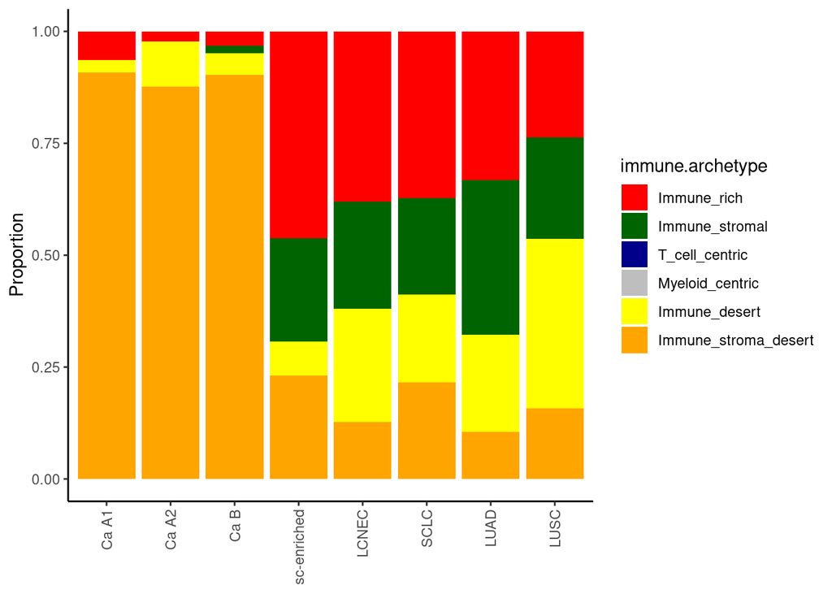

```r
ggimmunearc = ggplot( Immarc6.tib  , aes(x=group,y=Freq,fill=immune.archetype)) +
  geom_bar(stat="identity") +
  theme_classic() + theme(axis.text.x = element_text(angle=90,hjust=1,vjust=0.5),axis.title.x = element_blank()) +
  scale_fill_manual(values=immarc6) + ylab("Proportion")

ggimmunearc
```

```r
ggsave(ggimmunearc,filename = "../../../Figures/Fig1F_immunearcs.svg",height=3,width=5)

table(arc.features.df.long$group,arc.features.df.long$cluster.label)
```

```
##
##               Immune_rich Immune_stromal T_cell_centric Myeloid_centric
##   Ca A1                63              0              0               0
##   Ca A2                18              0              0               0
##   Ca B                 18              9              0               0
##   sc-enriched          54             27              0               0
##   LCNEC               243            153              0               0
##   SCLC                171             99              0               0
##   LUAD               1593           1665              0               0
##   LUSC               1071           1026              0               0
##
##               Immune_desert Immune_stroma_desert
##   Ca A1                  27                  891
##   Ca A2                  81                  702
##   Ca B                   27                  504
##   sc-enriched             9                   27
##   LCNEC                 162                   81
##   SCLC                   90                   99
##   LUAD                 1044                  504
##   LUSC                 1710                  711
```

## Panel G

### Load data

We first load the clinical data from Table S1

```r
var_cli = read_tsv("/home/alcalan/lungNENomics/var_cli_09052024.tsv")
```

We get quantiseq results from the quantiseq pipeline run with the official docker container (see pipeline at https://github.com/IARCbioinfo/quantiseq-nf)

```r
quantiseq = read_csv("/data/lungNENomics/work/Descriptive_manuscript_data/RNA_sequencing_data/quanTIseq_matrix_PCA_LCNEC_SCLC_ITH_TR.csv")[,-1]
```

```
## ──────────────────────────────────────────────────────── Delimiter: "," chr
## (1): sample_id dbl (12): ...1, B.cells, Macrophages.M1, Macrophages.M2,
## Monocytes, Neutroph...
```

```r
quantiseq = left_join(quantiseq,var_cli%>% dplyr::select(sample_id,group))
colnames(quantiseq)[2:12] = c( "B cell","Macrophage M1","Macrophage M2","Monocyte","Neutrophil","NK cell","T cell CD4+ (non-regulatory)",
                               "T cell CD8+","T cell regulatory (Tregs)","Myeloid dendritic cell","uncharacterized cell")

# normalize immune cells to sum to 1
quantiseq.norm = quantiseq[,c(1:11,13)]
#quantiseq.norm[,2:11] = sweep(quantiseq.norm[,2:11],1,rowSums(quantiseq.norm[,2:11]),"/")

quantiseq.long = quantiseq.norm %>% pivot_longer(cols = `B cell`:`Myeloid dendritic cell`,names_to = "Cell type",values_to = "Proportion")
```

### Plot cell type compositions

We define colors for the Cell types

```r
cell11 <- c("Myeloid dendritic cell"="#882E72","Monocyte"="#1965B0","Macrophage M2"="#5289C7","Macrophage M1"="#7BAFDE",
            "Neutrophil"="#4EB265","NK cell"="#CAE0AB","T cell CD4+ (non-regulatory)"="#F7F056","T cell CD8+"="#F4A736",
            "B cell"="#E8601C","T cell regulatory (Tregs)"="#DC050C","uncharacterized cell"="#72190E")
```

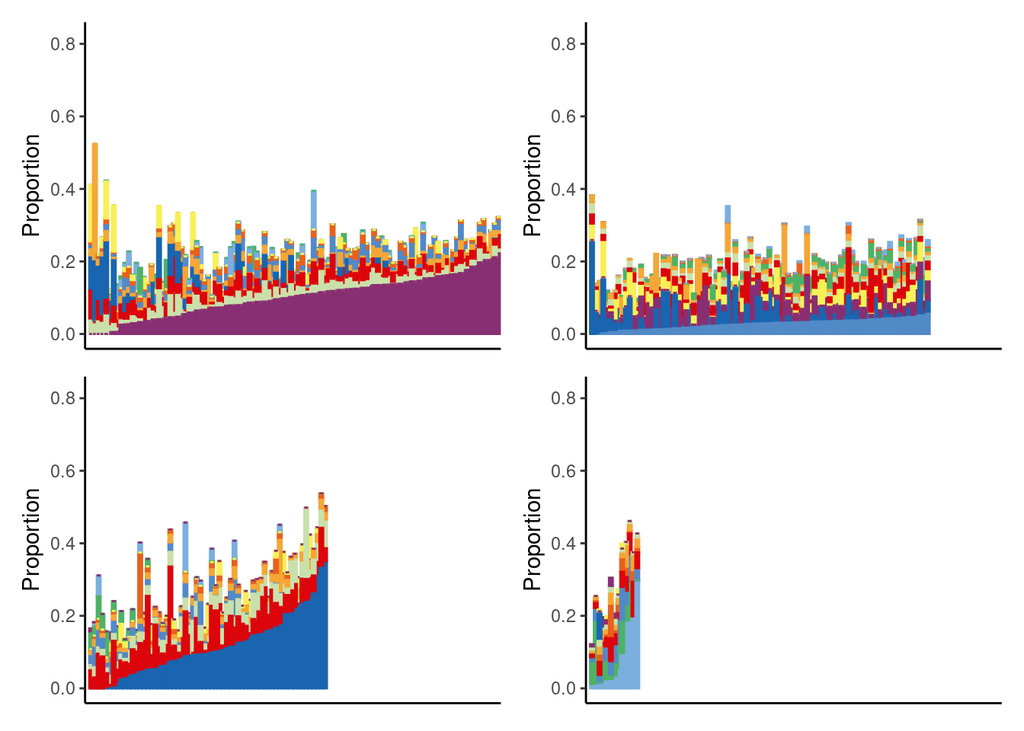

```r
Im.plot = ggplot(quantiseq.long, aes(x=group,y=value,fill=name)) + geom_bar(position = "stack", stat = "identity", width = 1) +
  theme_void() + ylab("") + theme(legend.position = "none") + facet_grid(.~group,scales = "free_x") + scale_fill_manual(values=cell11)

quantiseq.long.mean = quantiseq.long %>% group_by(group,`Cell type`) %>% summarize(Mean_prop = mean(Proportion))
# find max number of samples to scale all plots
nmax = max(table(quantiseq$group))
maxprop = max(quantiseq.long$Proportion)

# A1 plot
# reorder names
quantiseq.long$`Cell type` <- factor(as.character(quantiseq.long$`Cell type`), levels = quantiseq.long.mean %>% filter(group=="Ca A1") %>% arrange(-Mean_prop) %>% pull(`Cell type`) %>% rev())
quantiseq.long$sample_id   <- factor(as.character(quantiseq.long$sample_id), levels = quantiseq.long %>% arrange(`Cell type`,Proportion) %>% pull(sample_id) %>% rev() %>% unique() %>% rev())

Fig1G_A1 <- ggplot(quantiseq.long %>% filter(group=="Ca A1"), aes(fill = `Cell type`, color = `Cell type`, y = Proportion, x = sample_id)) +
    geom_bar(position = "stack", stat = "identity", width = 1) + theme_classic() +
  scale_fill_manual(values=cell11) + scale_color_manual(values=cell11) + coord_cartesian(xlim=c(0,nmax),ylim=c(0,maxprop)) +
    theme(legend.position = "none",axis.ticks.x = element_blank(),axis.text.x = element_blank(),axis.title.x = element_blank())

# A2 plot
# reorder names
quantiseq.long$`Cell type` <- factor(as.character(quantiseq.long$`Cell type`), levels = quantiseq.long.mean %>% filter(group=="Ca A2") %>% arrange(-Mean_prop) %>% pull(`Cell type`) %>% rev())
quantiseq.long$sample_id <- factor(as.character(quantiseq.long$sample_id), levels = quantiseq.long %>% arrange(`Cell type`,Proportion) %>% pull(sample_id) %>% rev() %>% unique() %>% rev())

Fig1G_A2 <- ggplot(quantiseq.long %>% filter(group=="Ca A2"), aes(fill = `Cell type`, color = `Cell type`, y = Proportion, x = sample_id)) +
    geom_bar(position = "stack", stat = "identity", width = 1) + theme_classic() +
  scale_fill_manual(values=cell11) + scale_color_manual(values=cell11) + coord_cartesian(xlim=c(0,nmax),ylim=c(0,maxprop)) +
    theme(legend.position = "none",axis.ticks.x = element_blank(),axis.text.x = element_blank(),axis.title.x = element_blank())

# B plot
# reorder names
quantiseq.long$`Cell type` <- factor(as.character(quantiseq.long$`Cell type`), levels = quantiseq.long.mean %>% filter(group=="Ca B") %>% arrange(-Mean_prop) %>% pull(`Cell type`) %>% rev())
quantiseq.long$sample_id <- factor(as.character(quantiseq.long$sample_id), levels = quantiseq.long %>% arrange(`Cell type`,Proportion) %>% pull(sample_id) %>% rev()%>% unique() %>% rev())

Fig1G_B <- ggplot(quantiseq.long %>% filter(group=="Ca B"), aes(fill = `Cell type`, color = `Cell type`, y = Proportion, x = sample_id)) +
    geom_bar(position = "stack", stat = "identity", width = 1) + theme_classic() +
  scale_fill_manual(values=cell11) + scale_color_manual(values=cell11) + coord_cartesian(xlim=c(0,nmax),ylim=c(0,maxprop)) +
    theme(legend.position = "none",axis.ticks.x = element_blank(),axis.text.x = element_blank(),axis.title.x = element_blank())

# supra-ca plot
# reorder names
quantiseq.long$`Cell type` <- factor(as.character(quantiseq.long$`Cell type`), levels = quantiseq.long.mean %>% filter(group=="sc-enriched") %>% arrange(-Mean_prop) %>% pull(`Cell type`) %>% rev())
quantiseq.long$sample_id <- factor(as.character(quantiseq.long$sample_id), levels = quantiseq.long %>% arrange(`Cell type`,Proportion) %>% pull(sample_id) %>% rev() %>% unique() %>% rev())

Fig1G_sce <- ggplot(quantiseq.long %>% filter(group=="sc-enriched"), aes(fill = `Cell type`, color = `Cell type`, y = Proportion, x = sample_id)) +
    geom_bar(position = "stack", stat = "identity", width = 1) + theme_classic() +
  scale_fill_manual(values=cell11) + scale_color_manual(values=cell11) + coord_cartesian(xlim=c(0,nmax),ylim=c(0,maxprop)) +
    theme(legend.position = "none",axis.ticks.x = element_blank(),axis.text.x = element_blank(),axis.title.x = element_blank())

Fig1G_A1 + Fig1G_A2 + Fig1G_B + Fig1G_sce
```

```r
ggsave(filename="../../../Figures/Fig1G_raw.svg",Fig1G_A1 + Fig1G_A2 + Fig1G_B + Fig1G_sce,width=2.5*2,height=2.5*2)
```